# Exercice 2 : compilation d’un fichier source

Télécharger le code source du document Exercice_2.Rmd en cliquant droit sur le lien précédent, et en enregistrant le fichier sous un répertoire pertinent où vous compilerez vos fichiers. Par défaut, le fichier sera compilé au même endroit que le code source, alors assurez-vous que le code source se trouve à un endroit pertinent et facile à retrouver.

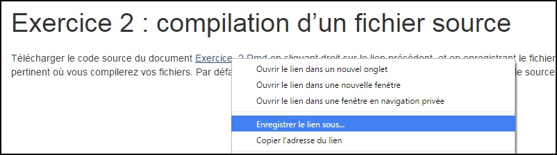

Maintenant que votre code source est enregistré, lancer la compilation à l’aide de la commande R

```r
rmarkdown::render("chemin\vers\le\dossier\Exercice_2.Rmd")
```

en prenant soin de remplacer `chemin\vers\le\dossier\` par le véritable chemin du dossier où vous avez enregistré le fichier **Exercice_2.Rmd**.

Dans RStudio, un aperçu du document que vous avez créé devrait apparaître dans une nouvelle fenêtre ou dans l’onglet **Viewer**. Comparer le code source au document HTML produit.

Pour les utilisateurs d’un autre éditeur, la version compilée est également disponible en fichier HTML à l’endroit où vous avez préalablement enregistré le code source **Exercice_2.Rmd** :

[figure not shown]

Ouvrir le fichier HTML produit et le comparer au code source.

Remarque : Dans RStudio, vous pouvez remplacer la commande `rmarkdown::render()` par une pression du bouton **Knit HTML**, tel qu’illustré :

[figure not shown]